# Housing

2025-10-21

# 1. Importar datos

```r
library("readr")
housing<-as.data.frame(read_csv("/Users/pau/Documents/CEU/Visualización/Housing.csv"))
```

### Estructura del conjunto de datos

```r
class(housing)
```

```
## [1] "data.frame"
```

```r
dim(housing)
```

```
## [1] 4600   18
```

```r
str(housing)
```

```
## 'data.frame':    4600 obs. of  18 variables:
##  $ date         : POSIXct, format: "2014-05-02" "2014-05-02" ...
##  $ price        : num  313000 2384000 342000 420000 550000 ...
##  $ bedrooms     : num  3 5 3 3 4 2 2 4 3 4 ...
##  $ bathrooms    : num  1.5 2.5 2 2.25 2.5 1 2 2.5 2.5 2 ...
##  $ sqft_living  : num  1340 3650 1930 2000 1940 880 1350 2710 2430 1520 ...
##  $ sqft_lot     : num  7912 9050 11947 8030 10500 ...
##  $ floors       : num  1.5 2 1 1 1 1 1 2 1 1.5 ...
##  $ waterfront   : num  0 0 0 0 0 0 0 0 0 0 ...
##  $ view         : num  0 4 0 0 0 0 0 0 0 0 ...
##  $ condition    : num  3 5 4 4 4 3 3 3 4 3 ...
##  $ sqft_above   : num  1340 3370 1930 1000 1140 880 1350 2710 1570 1520 ...
##  $ sqft_basement: num  0 280 0 1000 800 0 0 0 860 0 ...
##  $ yr_built     : num  1955 1921 1966 1963 1976 ...
##  $ yr_renovated : num  2005 0 0 0 1992 ...
##  $ street       : chr  "18810 Densmore Ave N" "709 W Blaine St" "26206-26214 143rd Ave SE" "857 170th Pl NE" ...
##  $ city         : chr  "Shoreline" "Seattle" "Kent" "Bellevue" ...
##  $ statezip     : chr  "WA 98133" "WA 98119" "WA 98042" "WA 98008" ...
##  $ country      : chr  "USA" "USA" "USA" "USA" ...
```

El archivo es un data frame que contiene 4600 observaciones y 18 variables.

# 2. Depuración de datos

```r
housing2<-subset(housing, select = -c(date, view, condition, street, statezip))
```

Eliminamos las variables date, view, condition, street and statezip.

```r
housing2$antiguedad <- 2025 - housing2$yr_built
```

Creamos una nueva variable llamada antigüedad, que nos indica cuántos años han pasado desde la construcción de la casa.

```r
housing2$price <- housing2$price * 0.86
```

Conviertimos la variable price a euros, sabiendo que 1 USD = 0,86 EUR.

### a. Identificamos valores perdidos

```r
sum(is.na(housing2))
```

```
## [1] 0
```

No se observan valores perdidos en el conjunto de datos.

### b. Identificamos el número de ciudades del estudio

```r
length(unique(housing2$city))
```

```
## [1] 44
```

### c. Identificamos las características de la vivienda más antigua y de la más nueva

```r
housing2[c(which.min(housing2$yr_built), which.max(housing2$yr_built)), ]
```

```
##     price bedrooms bathrooms sqft_living sqft_lot floors waterfront sqft_above
## 73 540080        4       2.0        2280     6010      1          0       1140
## 34 537500        4       2.5        2820     8408      2          0       2820
##    sqft_basement yr_built yr_renovated      city country antiguedad
## 73          1140     1900         2005   Seattle     USA        125
## 34             0     2014            0 Shoreline     USA         11
```

### d. Identificamos las viviendas que tienen más de 5 baños y más de 5 habitaciones y las ordenamos por la superficie habitable

```r
subset_houses <- housing2[housing2$bathrooms > 5 & housing2$bedrooms > 5, ]
subset_houses <- subset_houses[order(-subset_houses$sqft_living), ]
head(subset_houses)
```

```
##        price bedrooms bathrooms sqft_living sqft_lot floors waterfront
## 123  1960800        7      8.00       13540   307752      3          0
## 3005 1066400        7      5.50        6630    13782      2          0
## 292   464400        7      5.75        3700     7647      2          0
## 1018  258000        6      5.25        2860     5682      2          0
##      sqft_above sqft_basement yr_built yr_renovated             city country
## 123        9410          4130     1999            0          Redmond     USA
## 3005       4930          1700     2004         2003         Bellevue     USA
## 292        3700             0     1948         1984 Lake Forest Park     USA
## 1018       2860             0     1978            0           Auburn     USA
##      antiguedad
## 123          26
## 3005         21
## 292          77
## 1018         47
```

# 3. Descriptiva univariante

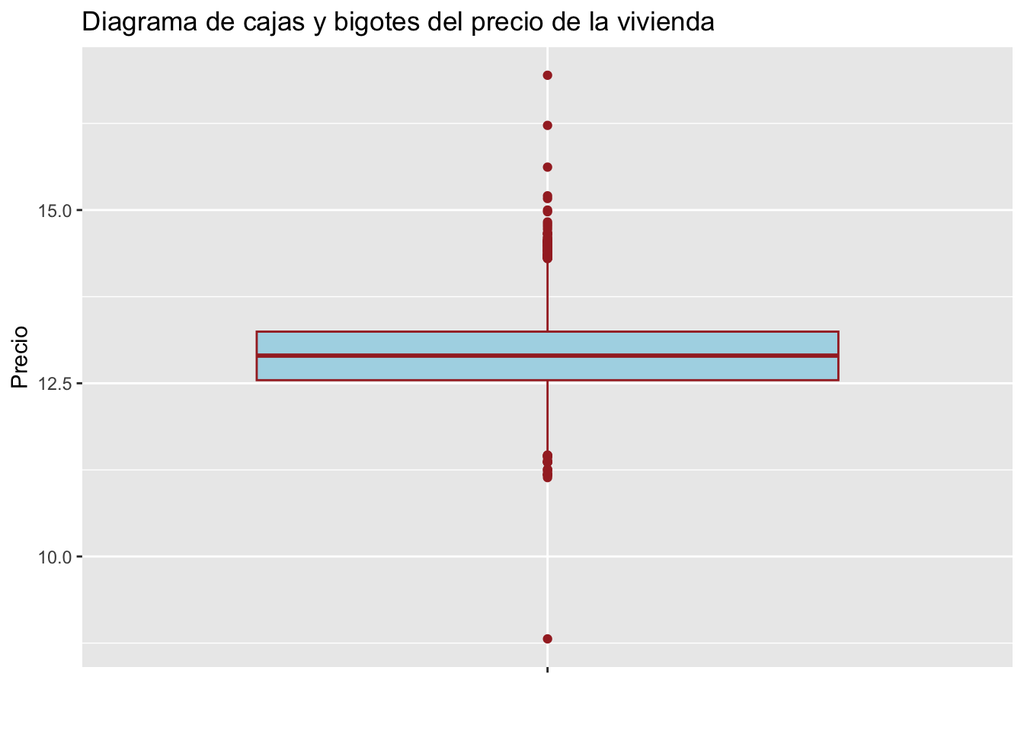

```r
library("ggplot2")
ggplot(data=housing2, aes(x=" ",y=log(price)))+
  geom_boxplot(col="brown",fill="lightblue")+
  labs(title="Diagrama de cajas y bigotes del precio de la vivienda",
      y="Precio",
      x=" ")
```

Boxplot de la variable price transformada.

```r
min(housing2$price)
```

```
## [1] 0
```

```r
length(which(housing2$price == 0))
```

```
## [1] 49
```

Hay 49 observaciones con un precio de 0EUR, se eliminan dichas observaciones:

```r
housing3<-subset(housing2, price != 0)
```

```r
medidas <- data.frame(
  Media=mean(housing3$price),
  Mediana=median(housing3$price),
  DT=sd(housing3$price),
  Varianza=var(housing3$price),
  IQR=IQR(housing3$price),
  P25=quantile(housing3$price,0.25),
  P75=quantile(housing3$price,0.75)
)
medidas
```

```
##        Media Mediana       DT     Varianza      IQR      P25    P75
## 25% 479799.1  399900 484979.7 235205299034 284862.7 280587.3 565450
```

Tabla con medidas descriptivas de la variable price.

```r
get_mode <- function(x) {
  ux <- unique(x)
  ux[which.max(tabulate(match(x, ux)))]
}
moda <- get_mode(housing3$bedrooms)
moda
```

```
## [1] 3
```

Número de habitaciones más frecuente en la base de datos.

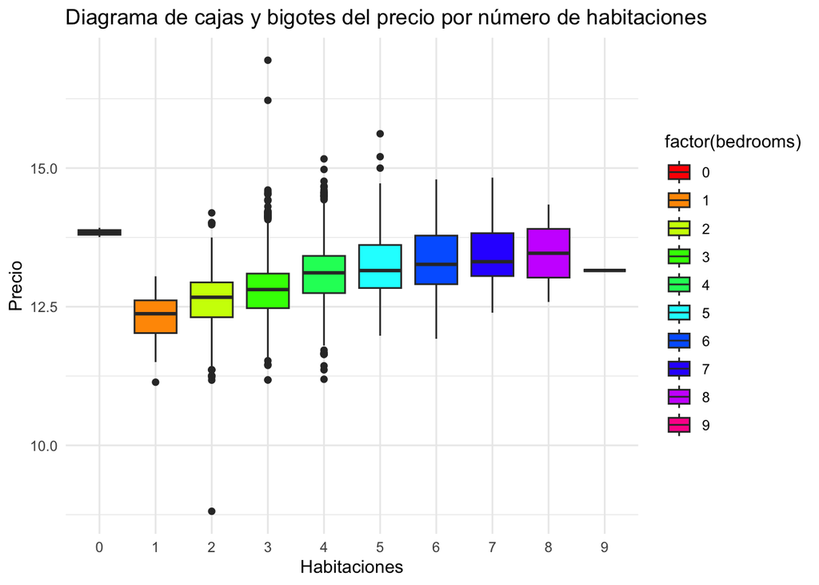

```r
library("ggplot2")
ggplot(data=housing3, aes(x=factor(bedrooms),y=log(price),fill=factor(bedrooms)))+
  geom_boxplot()+
  scale_fill_manual(values=rainbow(length(unique(housing3$bedrooms))))+
  labs(title="Diagrama de cajas y bigotes del precio por número de habitaciones",
    x="Habitaciones",
    y="Precio")+
theme_minimal()
```

Se observa una clara tendencia de aumento de precio mediano en función del número de habitaciones. Cabe destacar mayor presencia de valores atípicos en casas de 2 a 5 habitaciones, que son las más frecuentes en esta muestra, aunque los inmuebles en este rango presentan poca variación respecto a la mediana. Cuantas más habitaciones, más rango de precio hay. También se observa la escasez de datos en casas de 0 y 9 habitaciones.

# 4. Bidimensional

```r
housing4<-subset(housing3, housing3$city == c("Shoreline", "Redmond", "Sammamish"))
```

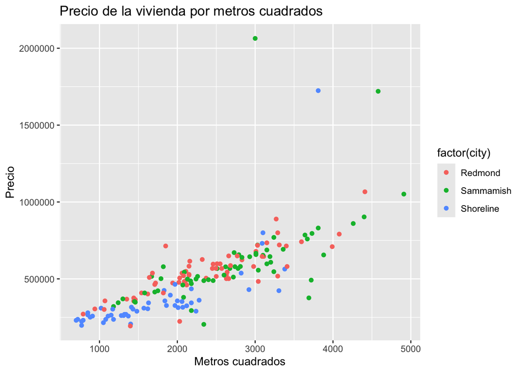

```r
library("ggplot2")
ggplot(data=housing4, aes(x=sqft_living,y=price,color=factor(city)))+
  geom_point()+
  scale_fill_manual(values=rainbow(length(unique(housing4$city))))+
  labs(title="Precio de la vivienda por metros cuadrados",
       y="Precio",
       x="Metros cuadrados")
```

```r
recta <- lm(housing4$sqft_living~housing4$price)
covarianza<-cov(housing4$sqft_living,housing4$price)
correlacion<-cor(housing4$price,housing4$sqft_living)
summary(recta)
```

```
##
## Call:
## lm(formula = housing4$sqft_living ~ housing4$price)
##
## Residuals:
##     Min      1Q  Median      3Q     Max
## -3400.6  -379.6    -2.1   327.4  1749.5
##
## Coefficients:
##                 Estimate Std. Error t value Pr(>|t|)
## (Intercept)    9.462e+02  1.050e+02   9.008 3.77e-16 ***
## housing4$price 2.643e-03  1.837e-04  14.388  < 2e-16 ***
## ---
## Signif. codes:  0 '***' 0.001 '**' 0.01 '*' 0.05 '.' 0.1 ' ' 1
##
## Residual standard error: 605.4 on 173 degrees of freedom
## Multiple R-squared:  0.5447, Adjusted R-squared:  0.5421
## F-statistic:   207 on 1 and 173 DF,  p-value: < 2.2e-16
```

```r
covarianza
```

```
## [1] 165016918
```

```r
correlacion
```

```
## [1] 0.7380641
```

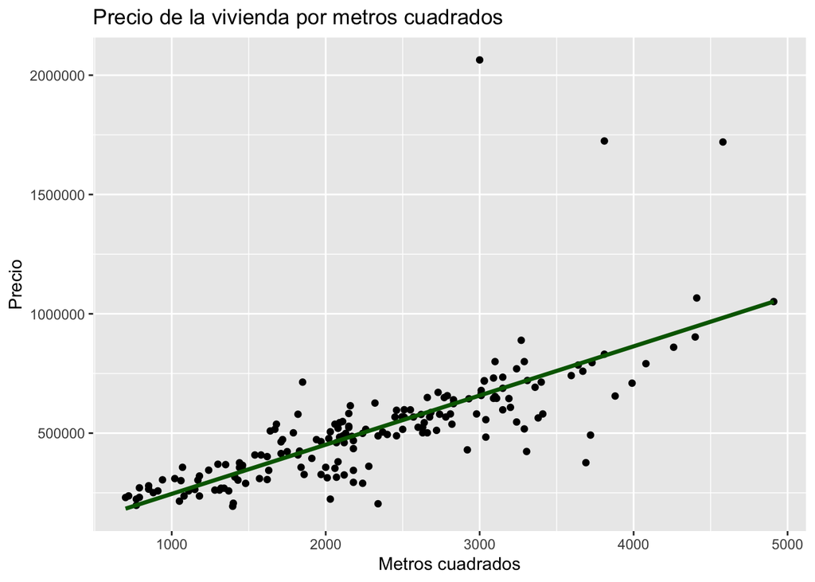

```r
library("ggplot2")
ggplot(housing4, aes(x=sqft_living,y=price)) +
  geom_point() +
  geom_smooth(method="lm",color="darkgreen",lwd=1.2,se=FALSE) +
  labs(title="Precio de la vivienda por metros cuadrados",
       x="Metros cuadrados",
       y="Precio")
```

El coeficiente de determinación (R^2 = 0.54) indica que el 54 % de la variabilidad de la variable dependiente puede ser explicada por el modelo. Parece haber una relación lineal clara entre el precio y la superficie en este conjunto de datos.

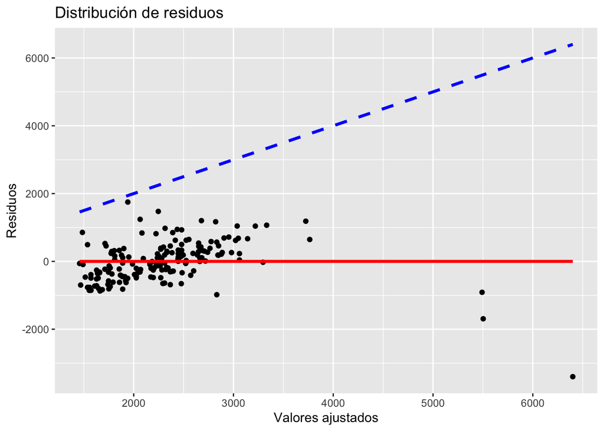

```r
residuos <- recta$residuals
valores_ajust <- recta$fitted.values

library("ggplot2")
ggplot(data=recta, aes(x=valores_ajust,y=residuos)) +
  geom_point() +
  geom_smooth(method="lm",color="red",lwd=1.2,se=FALSE) +
  geom_smooth(aes(y=valores_ajust),color="blue",lwd=1.2,linetype="dashed") +
  labs(title="Distribución de residuos",
       x="Valores ajustados",
       y="Residuos")
```

Hay una acumulación de observaciones con residuos tanto positivos como negativos, el patrón no aleatorio de dichos residuos indica que el modelo no captura completamente la relación entre las variables.

```r
slope<-recta$coefficients [1]
intercept<-recta$coefficients [2]
Precio100sqft<-slope*100+intercept
Precio200sqft<-slope*200+intercept
print(paste("Price for 100 sqft =", Precio100sqft))
```

```
## [1] "Price for 100 sqft = 94624.0878967718"
```

```r
print(paste("Price for 200 sqft =", Precio200sqft))
```

```
## [1] "Price for 200 sqft = 189248.173150904"
```